# rnorm for n00b

Lucien De Brot

## QNORM - Quantile Normal Distribution

**QNORM is useful for determining which chunk of the distribution amounts to a given probability**

**qnorm’s arguments**:

- p = probability of the distribution
- mean = mean of the distribution
- sd = standard deviation of the distribution
- lower.tail = TRUE if you want the quantile at which ends the probability chunk (thus situated left of the quantile); =FALSE if you want the quantile at which ends the probability chunk (thus situated right of the quantile)

**For example**: In a normal distribution of 10000 people’s heights (with mean 174 and the standard deviation at 10), we would like to know which height range covers 80% of all heights. In other words, which are the 80% most common heights?

**qnorm’s arguments as used in our example**:

- p = 0.1 (because we want the “inner” 80% in this particular example. We therefore cut off 10% from each end.). The lower.tail arguments will from which end we count the probability mass.
- mean = mean of our test distribution = 174
- sd = standard deviation of our test distribution = 10
- lower.tail = TRUE to get the quantile from which starts the 80% range (<10%), FALSE to get the quantile at which ends the 80% (<90%)

```r
# Generate our test distribution
test_pop <- rnorm(n=10000,mean=174,sd=10)

# Now let us calculate the respective quantiles, giving us both ends of the "80% range"
qex_left <- qnorm(p=.1,mean=mean(test_pop),sd=sd(test_pop),lower.tail = TRUE)
qex_right <- qnorm(p=.1,mean=mean(test_pop),sd=sd(test_pop),lower.tail = FALSE)
print(round(c(qex_left,qex_right),2))
```

```
## [1] 161.16 186.83
```

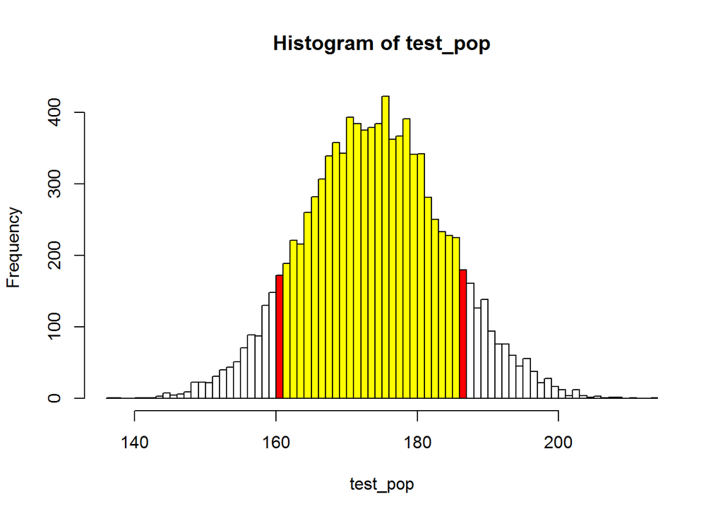

```r
# A nicely colored plot to illustrate our result
h <- hist(test_pop, breaks=100, plot = FALSE)
brks <- h$breaks[which(h$breaks>qex_left & h$breaks<qex_right)]
binylw <- cut(brks, h$breaks)
brks <- h$breaks[which(h$breaks %in% round(c(qex_left,qex_right),0))]
binred <- cut(brks, h$breaks)
clr <- rep("white", length(h$counts))
clr[binylw] <- "yellow"
clr[binred] <- "red"
plot(h, col=clr)
```

*Please note that this example is rather extraordinary. Instead of using 0.8 as our probability (for the 80% for which we are looking), we used .1 twice. The histogram above shows two results provided by qnorm : the quantile at 10% and 90% of the distribution respectively (in red). The bars in between are coloured for your convenience, but do not result from our caculations*

**What goes in, what comes out**:

- **Input**: probability (*p*), information about the distribution (*mean and sd*) and indication which part of the distribution (*lower.tail*)
- **Output**: The quantile on the lower or upper end of the probability chunk